# 568CCourseProj

## FITTING MODEL

 Identify the predictors and data type of the predictors

```r
predictor_names <- c("CPI","Debt_GDP","Year")


for(pname in predictor_names)
{
  print(typeof(train_data[,pname]))
}
```

```
## [1] "double"
## [1] "double"
## [1] "double"
```

```r
train_data1 <- as.data.frame(cbind(train_data$Year,train_data$CPI,train_data$Debt_GDP))
colnames(train_data1) <- c("Year", "CPI","Debt_GDP")
cormat <- round(cor(train_data1, use="pairwise.complete.obs"),2)
head(cormat)
```

```
##          Year  CPI Debt_GDP
## Year     1.00 1.00     0.65
## CPI      1.00 1.00     0.69
## Debt_GDP 0.65 0.69     1.00
```

```r
upper<-cormat
upper[upper.tri(cormat)]<-""
upper<-as.data.frame(upper)
upper
```

```
##          Year  CPI Debt_GDP
## Year        1
## CPI         1    1
## Debt_GDP 0.65 0.69        1
```

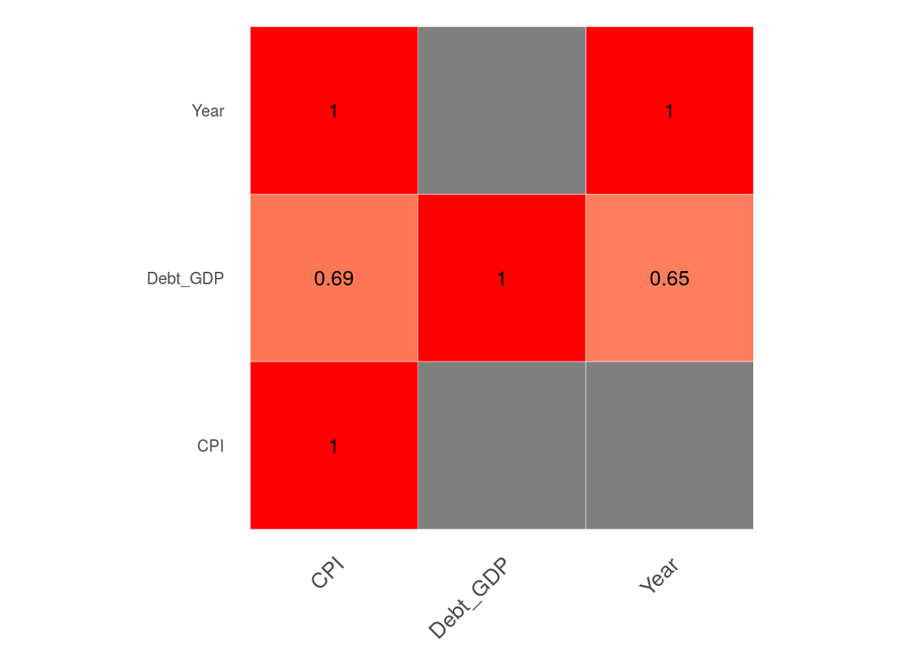

```r
get_lower_tri<-function(cormat){
    cormat[upper.tri(cormat)] <- NA
    return(cormat)
  }
  # Get upper triangle of the correlation matrix
  get_upper_tri <- function(cormat){
    cormat[lower.tri(cormat)]<- NA
    return(cormat)
  }

reorder_cormat <- function(cormat){
# Use correlation between variables as distance
dd <- as.dist((1-cormat)/2)
hc <- hclust(dd)
cormat <-cormat[hc$order, hc$order]
}

upper_tri <- get_upper_tri(cormat)
lower_tri <- get_lower_tri(cormat)

cormat <- reorder_cormat(cormat)
upper_tri <- get_upper_tri(cormat)
# Melt the correlation matrix
melted_cormat <- melt(upper_tri, na.rm = TRUE)
# Create a ggheatmap
ggheatmap <- ggplot(melted_cormat, aes(X2, X1, fill = value))+
 geom_tile(color = "white")+
 scale_fill_gradient2(low = "blue", high = "red", mid = "white",
   midpoint = 0, limit = c(-1,1), space = "Lab",
    name="Pearson\nCorrelation") +
  theme_minimal()+ # minimal theme
 theme(axis.text.x = element_text(angle = 45, vjust = 1,
    size = 12, hjust = 1))+
 coord_fixed()
# Print the heatmap


ggheatmap <- ggheatmap +
geom_text(aes(X2, X1, label = value), color = "black", size = 4) +
theme(
  axis.title.x = element_blank(),
  axis.title.y = element_blank(),
  panel.grid.major = element_blank(),
  panel.border = element_blank(),
  panel.background = element_blank(),
  axis.ticks = element_blank(),
  legend.justification = c(1, 3),
  legend.position = c(-0.5, 0.7),
  legend.direction = "horizontal")+
  guides(fill = guide_colorbar(barwidth = 7, barheight = 1,
                title.position = "left", title.hjust = .8))

print(ggheatmap)
```

Removed ‘year’ pedictor as year was highly correlated with CPI

## LINEAR REGRESSION

Verify the association between price and predictor variables

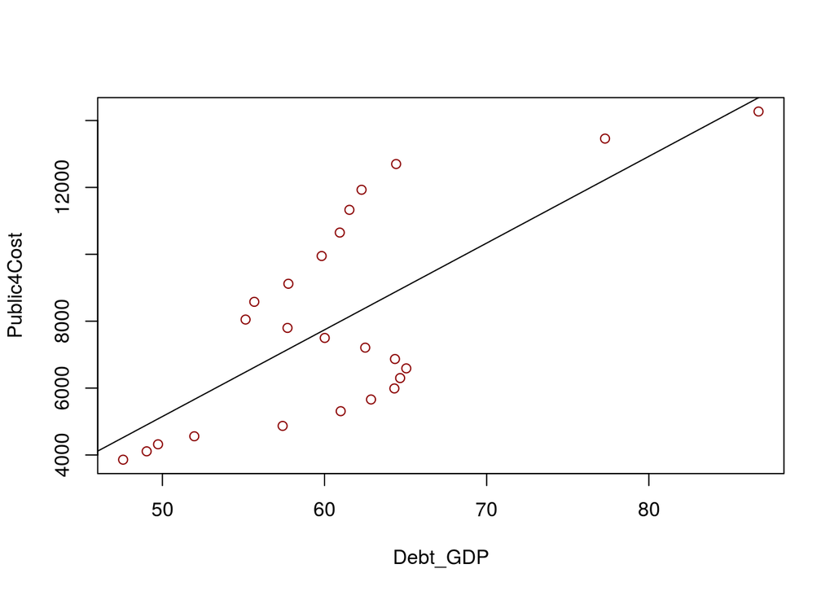

```r
# Public 4 Year cost and Debt GDP
plot(Public4Cost ~ Debt_GDP, data=train_data, col="darkred")
abline(lm(Public4Cost ~ Debt_GDP, data=train_data))
```

```r
#summary(lm(Public4Cost ~ Debt_GDP, data=train_data))

# TEST FOR NULL HYPOTHESIS
# E(FEV) = alpha + beta * Debt_GDP
# H0 : beta = 0
n=nrow(train_data)
Y=train_data$Public4Cost
X=cbind(rep(1,n),train_data$Debt_GDP)
p=ncol(X)
beta=solve(t(X) %*% X) %*% t(X) %*% Y
muhat= X %*% beta
sigmasq=sum((Y - muhat)^2)/(n-p)
covbeta=sigmasq * solve(t(X) %*% X)
sebeta=sqrt(diag(covbeta))
data.frame(beta,sebeta)
```

```
##         beta     sebeta
## 1 -7811.7348 3425.15314
## 2   259.2587   55.80052
```

```r
z=beta[2]/sebeta[2]
p=2*pt(z,df=n-2,lower.tail=FALSE)
data.frame(z,p)
```

```
##          z            p
## 1 4.646171 0.0001245065
```

```r
#Conclusion: The null hypothesis test is statistically significant, therefore there exists a linear association between Public4Cost and Debt_GDP
```

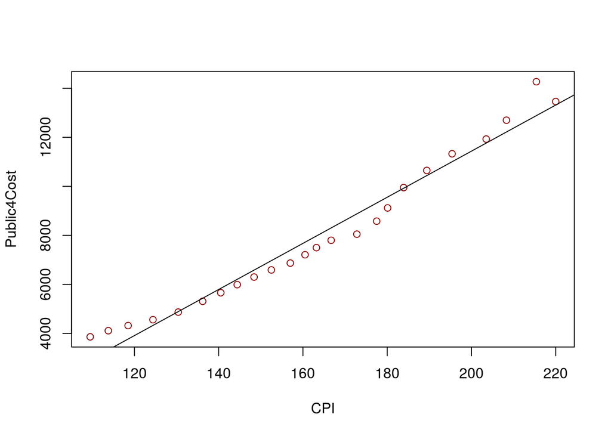

```r
# Public 4 Year cost and CPI
plot(Public4Cost ~ CPI, data=train_data, col="darkred")
abline(lm(Public4Cost ~ CPI, data=train_data))
```

```r
#summary(lm(Public4Cost ~ CPI, data=train_data))

# TEST FOR NULL HYPOTHESIS
# E(FEV) = alpha + beta * CPI
# H0 : beta = 0
n=nrow(train_data)
Y=train_data$Public4Cost
X=cbind(rep(1,n),train_data$CPI)
p=ncol(X)
beta=solve(t(X) %*% X) %*% t(X) %*% Y
muhat= X %*% beta
sigmasq=sum((Y - muhat)^2)/(n-p)
covbeta=sigmasq * solve(t(X) %*% X)
sebeta=sqrt(diag(covbeta))
data.frame(beta,sebeta)
```

```
##          beta     sebeta
## 1 -7375.68519 599.942091
## 2    94.06396   3.612348
```

```r
z=beta[2]/sebeta[2]
p=2*pt(z,df=n-2,lower.tail=FALSE)
data.frame(z,p)
```

```
##          z            p
## 1 26.03956 5.038646e-18
```

```r
#Conclusion: The null hypothesis test is statistically significant, therefore there exists a linear association between Public4Cost and CPI
```

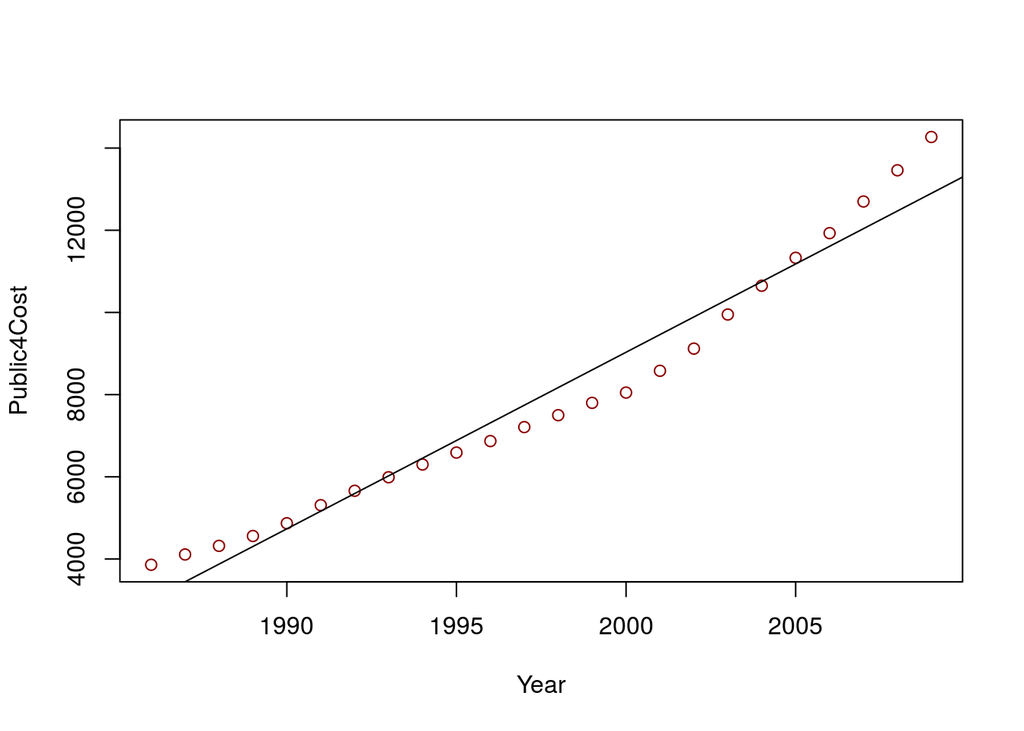

```r
# Public 4 Year cost and Year
plot(Public4Cost ~ Year, data=train_data, col="darkred")
abline(lm(Public4Cost ~ Year, data=train_data))
```

```r
#summary(lm(Public4Cost ~ Year, data=train_data))

# TEST FOR NULL HYPOTHESIS
# E(FEV) = alpha + beta * Year
# H0 : beta = 0
n=nrow(train_data)
Y=train_data$Public4Cost
X=cbind(rep(1,n),train_data$Year)
p=ncol(X)
beta=solve(t(X) %*% X) %*% t(X) %*% Y
muhat= X %*% beta
sigmasq=sum((Y - muhat)^2)/(n-p)
covbeta=sigmasq * solve(t(X) %*% X)
sebeta=sqrt(diag(covbeta))
data.frame(beta,sebeta)
```

```
##        beta     sebeta
## 1 -850367.8 37781.7467
## 2     429.7    18.9144
```

```r
z=beta[2]/sebeta[2]
p=2*pt(z,df=n-2,lower.tail=FALSE)
data.frame(z,p)
```

```
##          z           p
## 1 22.71814 9.14378e-17
```

```r
#Conclusion: The null hypothesis test is statistically significant, therefore there exists a linear association between Public4Cost and Year
```

Check for correation between public4cost and predictor variables

```r
# CHECK FOR POSSIBLE CORRELATION BETWEEN OUTPUT AND PREDICTOR VARIABLES
cor.test(train_data$Public4Cost,train_data$Debt_GDP, method = "pearson")
```

```
##
##  Pearson's product-moment correlation
##
## data:  train_data$Public4Cost and train_data$Debt_GDP
## t = 4.6462, df = 22, p-value = 0.0001245
## alternative hypothesis: true correlation is not equal to 0
## 95 percent confidence interval:
##  0.4194203 0.8623363
## sample estimates:
##      cor
## 0.703748
```

```r
cor.test(train_data$Public4Cost,train_data$CPI, method = "pearson")
```

```
##
##  Pearson's product-moment correlation
##
## data:  train_data$Public4Cost and train_data$CPI
## t = 26.04, df = 22, p-value < 2.2e-16
## alternative hypothesis: true correlation is not equal to 0
## 95 percent confidence interval:
##  0.9631379 0.9932361
## sample estimates:
##       cor
## 0.9841616
```

```r
cor.test(train_data$Public4Cost,train_data$Year, method = "pearson")
```

```
##
##  Pearson's product-moment correlation
##
## data:  train_data$Public4Cost and train_data$Year
## t = 22.718, df = 22, p-value < 2.2e-16
## alternative hypothesis: true correlation is not equal to 0
## 95 percent confidence interval:
##  0.9520820 0.9911668
## sample estimates:
##       cor
## 0.9793449
```

Check for correation between predictor variables

```r
# CHECK FOR POSSIBLE CORRELATION BETWEEN THE PREDICTOR VARIABLES
cor.test(train_data$CPI,train_data$Debt_GDP, method = "pearson")
```

```
##
##  Pearson's product-moment correlation
##
## data:  train_data$CPI and train_data$Debt_GDP
## t = 4.4457, df = 22, p-value = 0.0002031
## alternative hypothesis: true correlation is not equal to 0
## 95 percent confidence interval:
##  0.3938089 0.8542573
## sample estimates:
##       cor
## 0.6879215
```

```r
cor.test(train_data$CPI,train_data$Year, method = "pearson")
```

```
##
##  Pearson's product-moment correlation
##
## data:  train_data$CPI and train_data$Year
## t = 54.168, df = 22, p-value < 2.2e-16
## alternative hypothesis: true correlation is not equal to 0
## 95 percent confidence interval:
##  0.9912526 0.9984135
## sample estimates:
##      cor
## 0.996272
```

```r
cor.test(train_data$Year,train_data$Debt_GDP, method = "pearson")
```

```
##
##  Pearson's product-moment correlation
##
## data:  train_data$Year and train_data$Debt_GDP
## t = 4.022, df = 22, p-value = 0.0005716
## alternative hypothesis: true correlation is not equal to 0
## 95 percent confidence interval:
##  0.3357032 0.8350646
## sample estimates:
##       cor
## 0.6509476
```

```r
summary(lm(Public4Cost ~ CPI, data=train_data))
```

```
##
## Call:
## lm(formula = Public4Cost ~ CPI, data = train_data)
##
## Residuals:
##     Min      1Q  Median      3Q     Max
## -828.57 -452.81  -73.04  256.99 1384.31
##
## Coefficients:
##              Estimate Std. Error t value Pr(>|t|)
## (Intercept) -7375.685    599.942  -12.29 2.49e-11 ***
## CPI            94.064      3.612   26.04  < 2e-16 ***
## ---
## Signif. codes:  0 '***' 0.001 '**' 0.01 '*' 0.05 '.' 0.1 ' ' 1
##
## Residual standard error: 562.4 on 22 degrees of freedom
## Multiple R-squared:  0.9686, Adjusted R-squared:  0.9671
## F-statistic: 678.1 on 1 and 22 DF,  p-value: < 2.2e-16
```

```r
summary(lm(Public4Cost ~ Debt_GDP, data=train_data))
```

```
##
## Call:
## lm(formula = Public4Cost ~ Debt_GDP, data = train_data)
##
## Residuals:
##     Min      1Q  Median      3Q     Max
## -2870.4 -2051.1  -538.2  1955.5  3811.4
##
## Coefficients:
##             Estimate Std. Error t value Pr(>|t|)
## (Intercept)  -7811.7     3425.2  -2.281 0.032611 *
## Debt_GDP       259.3       55.8   4.646 0.000125 ***
## ---
## Signif. codes:  0 '***' 0.001 '**' 0.01 '*' 0.05 '.' 0.1 ' ' 1
##
## Residual standard error: 2254 on 22 degrees of freedom
## Multiple R-squared:  0.4953, Adjusted R-squared:  0.4723
## F-statistic: 21.59 on 1 and 22 DF,  p-value: 0.0001245
```

```r
summary(lm(Public4Cost ~ CPI + Debt_GDP, data=train_data))
```

```
##
## Call:
## lm(formula = Public4Cost ~ CPI + Debt_GDP, data = train_data)
##
## Residuals:
##    Min     1Q Median     3Q    Max
## -689.5 -440.7 -141.9  327.0 1074.3
##
## Coefficients:
##              Estimate Std. Error t value Pr(>|t|)
## (Intercept) -7968.704    855.736  -9.312 6.65e-09 ***
## CPI            90.729      4.983  18.207 2.43e-14 ***
## Debt_GDP       18.688     19.207   0.973    0.342
## ---
## Signif. codes:  0 '***' 0.001 '**' 0.01 '*' 0.05 '.' 0.1 ' ' 1
##
## Residual standard error: 563 on 21 degrees of freedom
## Multiple R-squared:  0.9699, Adjusted R-squared:  0.9671
## F-statistic: 338.7 on 2 and 21 DF,  p-value: < 2.2e-16
```

```r
#The coeﬃcient of Debt_GDP decreases when CPI is added to the model 2 because CPI and Debt_GDP are correlated in the sample. The estimate of coefficient of Debt_GDP when CPI predictor variable is NOT added only depends on the predictor variable Debt_GDP WHEREAS estimate of coefficient of Debt_GDP when CPI predictor variable is added not only depends on the predictor variable Debt_GDP, but also depends on CPI predictor variable. In eﬀect we have “controlled” CPI (or adjusted for CPI). We say that CPI is “confounding” the association between Public4cost and Debt_GDP. By adjusting for CPI, we remove its confounding eﬀect.

#Also, R^2 increases with addition of predictors because variability increases.
```

Interactions effect between predictors

```r
summary(lm(Public4Cost ~ Debt_GDP * CPI, data=train_data))
```

```
##
## Call:
## lm(formula = Public4Cost ~ Debt_GDP * CPI, data = train_data)
##
## Residuals:
##     Min      1Q  Median      3Q     Max
## -652.22 -229.41   57.76  162.09  522.71
##
## Coefficients:
##               Estimate Std. Error t value Pr(>|t|)
## (Intercept)  5622.6850  2315.1048   2.429   0.0247 *
## Debt_GDP     -218.9689    41.1441  -5.322 3.29e-05 ***
## CPI            17.4671    12.5321   1.394   0.1787
## Debt_GDP:CPI    1.2686     0.2105   6.026 6.84e-06 ***
## ---
## Signif. codes:  0 '***' 0.001 '**' 0.01 '*' 0.05 '.' 0.1 ' ' 1
##
## Residual standard error: 343.8 on 20 degrees of freedom
## Multiple R-squared:  0.9893, Adjusted R-squared:  0.9877
## F-statistic: 617.6 on 3 and 20 DF,  p-value: < 2.2e-16
```

```r
# E(Cost) = alpha + beta1 * CPI + beta2 * Debt_GDP + beta3 * CPI * Debt_GDP
mr01 = lm(Public4Cost ~ CPI + Debt_GDP + Debt_GDP * CPI, data=train_data)
summary(mr01)
```

```
##
## Call:
## lm(formula = Public4Cost ~ CPI + Debt_GDP + Debt_GDP * CPI, data = train_data)
##
## Residuals:
##     Min      1Q  Median      3Q     Max
## -652.22 -229.41   57.76  162.09  522.71
##
## Coefficients:
##               Estimate Std. Error t value Pr(>|t|)
## (Intercept)  5622.6850  2315.1048   2.429   0.0247 *
## CPI            17.4671    12.5321   1.394   0.1787
## Debt_GDP     -218.9689    41.1441  -5.322 3.29e-05 ***
## CPI:Debt_GDP    1.2686     0.2105   6.026 6.84e-06 ***
## ---
## Signif. codes:  0 '***' 0.001 '**' 0.01 '*' 0.05 '.' 0.1 ' ' 1
##
## Residual standard error: 343.8 on 20 degrees of freedom
## Multiple R-squared:  0.9893, Adjusted R-squared:  0.9877
## F-statistic: 617.6 on 3 and 20 DF,  p-value: < 2.2e-16
```

#—————————————- Checking the assumptions for Linear regression:  Normality of error distribution or large sample size  Constant variance of errors  Linearity  Independence

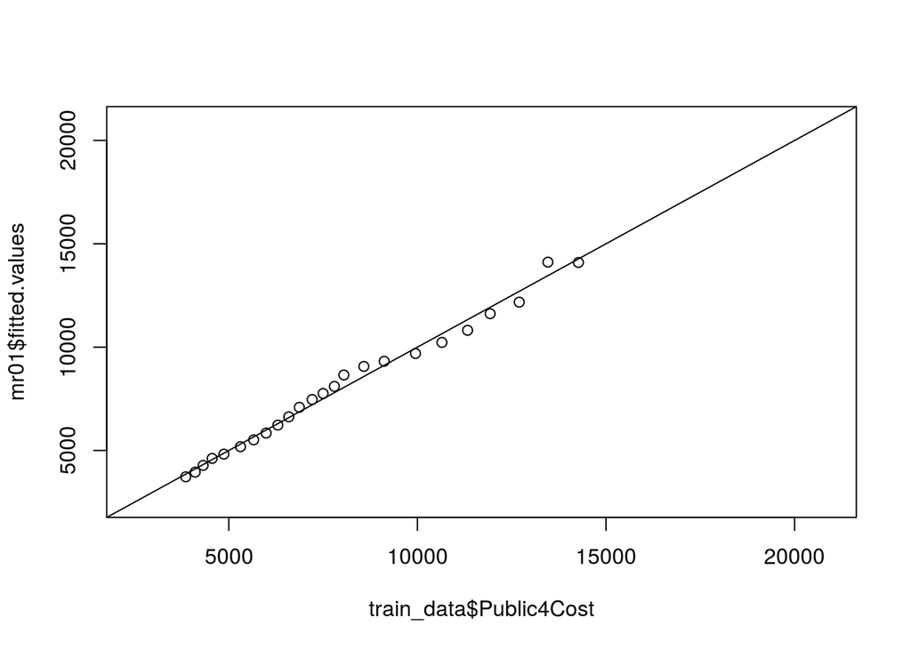

```r
## check out fitted values against the originals
#mr01
plot(train_data$Public4Cost, mr01$fitted.values, xlim = c(2500,20900), ylim = c(2500,20900))
abline(a=0, b=1)
```

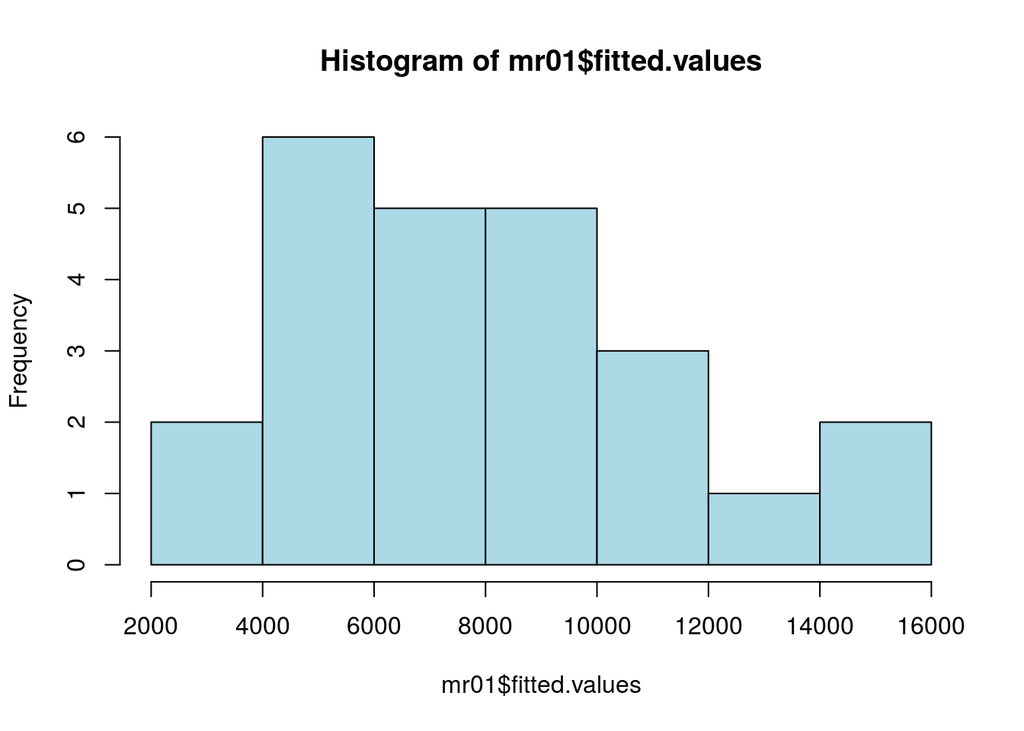

```r
hist(mr01$fitted.values,col="lightblue")
```

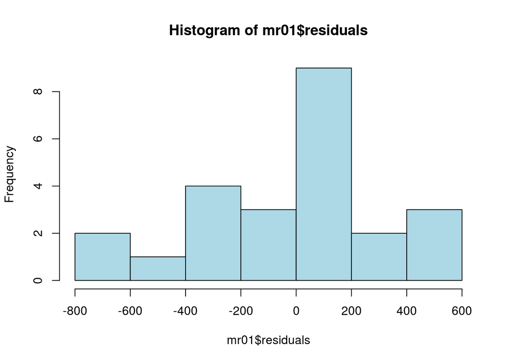

```r
#Check for normality using residuals - Data looks skewed
hist(mr01$residuals,col="lightblue")
```

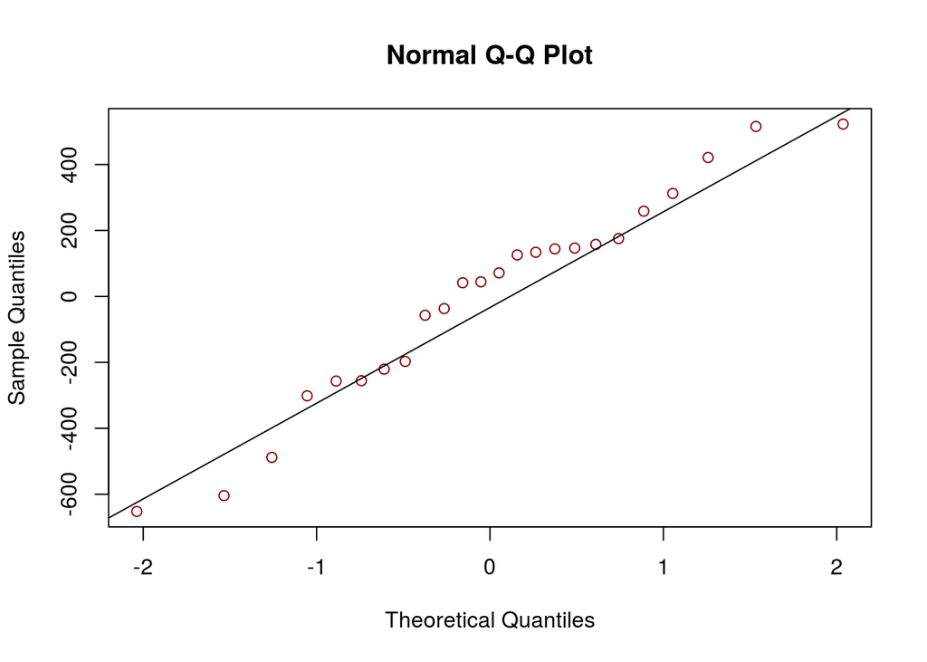

```r
qqnorm(mr01$residuals,col="darkred")
qqline(mr01$residuals)
```

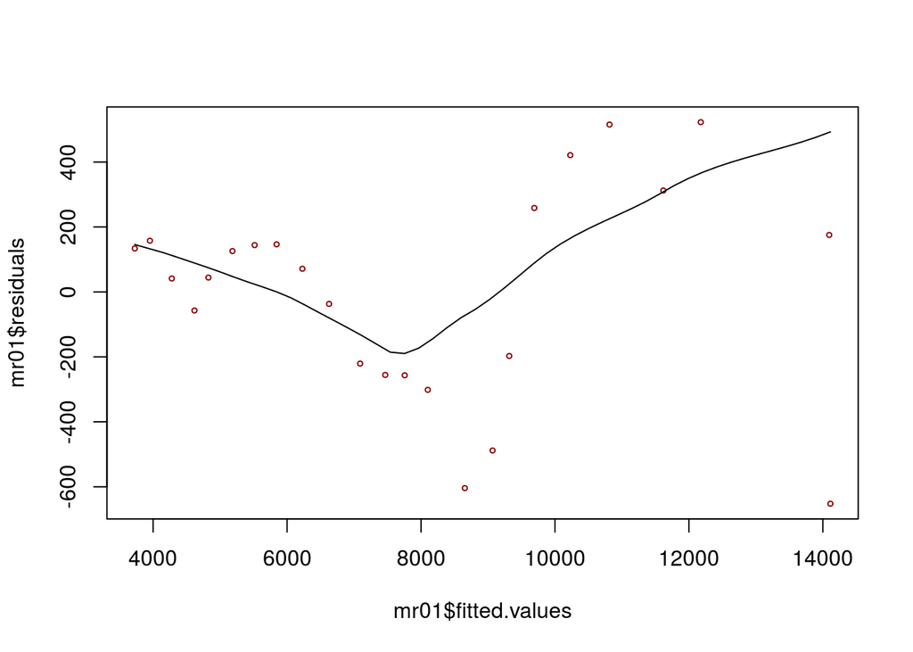

```r
# Check for constant-variance
scatter.smooth(mr01$fitted.values, mr01$residuals,cex=0.5,col="darkred")
```

```r
## MSE and RMSE
mean((mr01$fitted.values - train_data$Public4Cost)^2)
```

```
## [1] 98510.82
```

```r
sqrt(mean((mr01$fitted.values - train_data$Public4Cost)^2))
```

```
## [1] 313.8643
```

Linear regression did not meet the normality assumptions. Also, the sample size is very small.

```r
#Using log-tranformation of the response variable as residuals are not normal
mr02 <- (lm(log(Public4Cost) ~ CPI+Debt_GDP+CPI*Debt_GDP, data=train_data))
```

#——————————————–

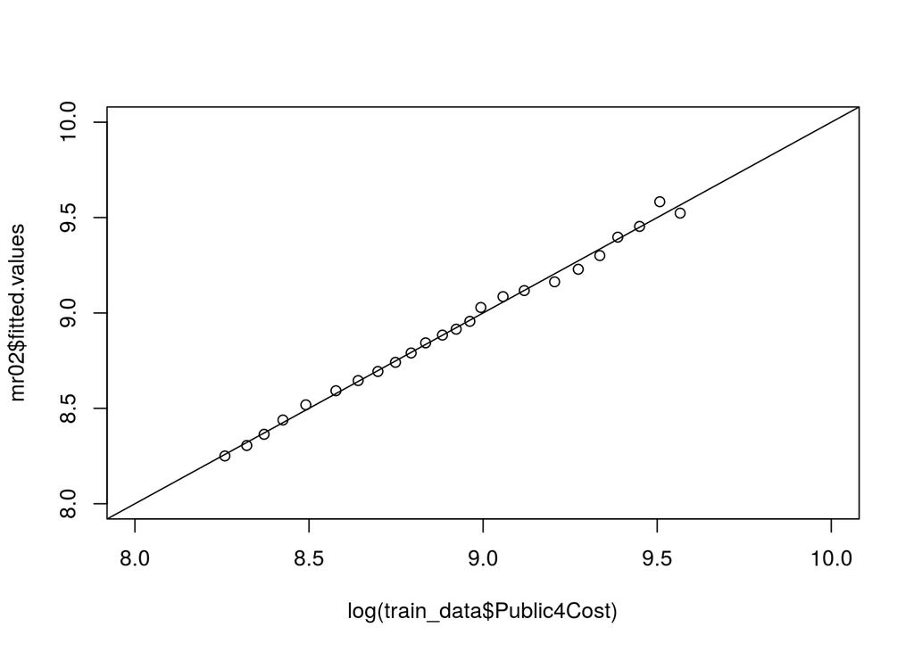

```r
## check out fitted values against the originals
#mr02
plot(log(train_data$Public4Cost), mr02$fitted.values, xlim = c(8,10), ylim = c(8,10))
abline(a=0, b=1)
```

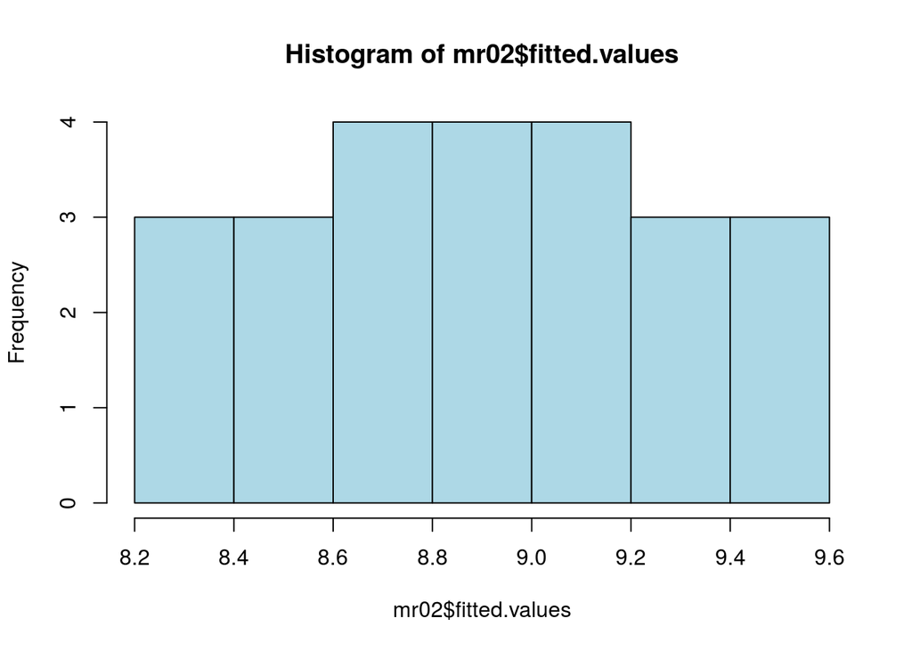

```r
# normality of errors
hist(mr02$fitted.values,col="lightblue")
```

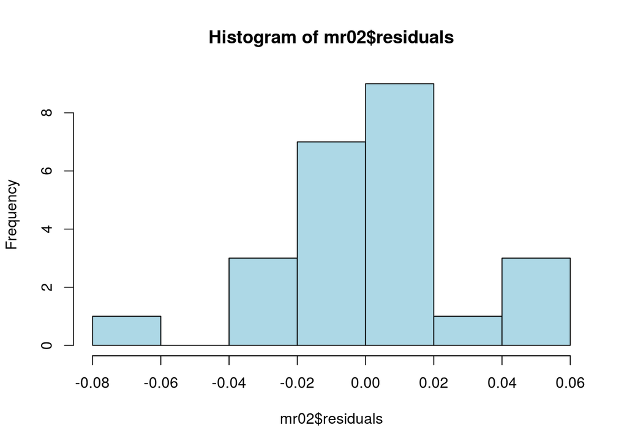

```r
#Check for normality using residuals - Data looks slightly normal
hist(mr02$residuals,col="lightblue")
```

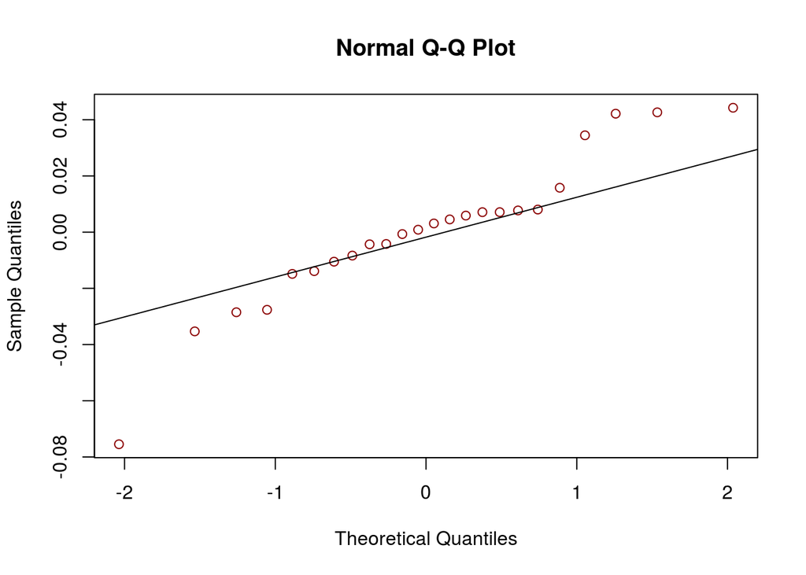

```r
qqnorm(mr02$residuals,col="darkred")
qqline(mr02$residuals)
```

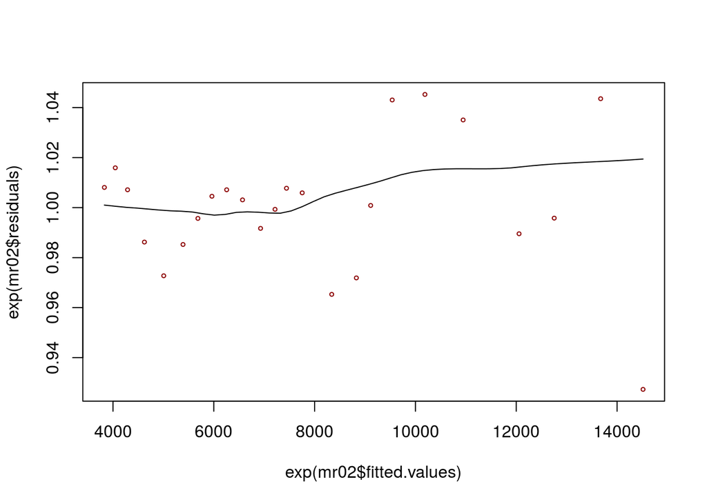

```r
# Check for constant-variance
scatter.smooth(exp(mr02$fitted.values), exp(mr02$residuals),cex=0.5,col="darkred")
```

```r
## MSE and RMSE
mean((exp(mr02$fitted.values) - train_data$Public4Cost)^2)
```

```
## [1] 92019.36
```

```r
sqrt(mean((exp(mr02$fitted.values) - train_data$Public4Cost)^2))
```

```
## [1] 303.3469
```

## GLM MODEL

```r
##Permutation Test for small sample before GLM
glm01 <- glm(Public4Cost ~ CPI + Debt_GDP + Debt_GDP * CPI,family = poisson,data =train_data)

set.seed(0)
beta=rep(NA,10000)
for(i in 1:10000){
  x1=sample(train_data$CPI,size=length(train_data$Public4Cost),replace=FALSE)
  x = x1+train_data$Debt_GDP+x1 * train_data$Debt_GDP
  beta[i]=glm(Public4Cost ~ x, data=data.frame(Public4Cost=train_data$Public4Cost,x), family=poisson)$coef[2]
}

mean(abs(beta) > abs(glm01$coef[2]))
```

```
## [1] 0
```

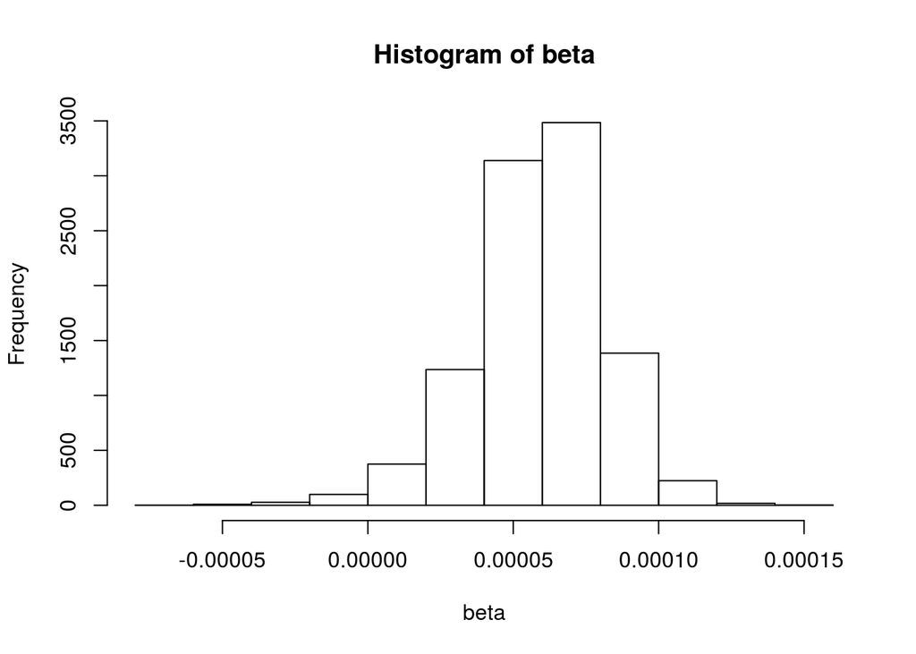

```r
hist(beta)
abline(v=glm01$coef[2],lty=2,col=2,lwd=2)
```

Permutation test p-value is statistically significant, so the sample size of 24 is good enough for doing GLM

```r
D=summary(glm01)$deviance
df=summary(glm01)$df.residual
data.frame(D,df,dispersion=D/df)
```

```
##          D df dispersion
## 1 181.5282 20   9.076408
```

```r
glmsum = summary(glm01,dispersion=D/df)
glmsum$coef
```

```
##                   Estimate   Std. Error   z value      Pr(>|z|)
## (Intercept)   6.612379e+00 2.798489e-01 23.628390 1.969005e-123
## CPI           1.375762e-02 1.401228e-03  9.818261  9.395011e-23
## Debt_GDP      6.018621e-03 4.859138e-03  1.238619  2.154866e-01
## CPI:Debt_GDP -3.085011e-05 2.347741e-05 -1.314034  1.888347e-01
```

```r
## review the model summary
summary(glm01,dispersion=D/df)
```

```
##
## Call:
## glm(formula = Public4Cost ~ CPI + Debt_GDP + Debt_GDP * CPI,
##     family = poisson, data = train_data)
##
## Deviance Residuals:
##     Min       1Q   Median       3Q      Max
## -8.4761  -1.0160  -0.1702   0.7496   5.2770
##
## Coefficients:
##                Estimate Std. Error z value Pr(>|z|)
## (Intercept)   6.612e+00  2.798e-01  23.628   <2e-16 ***
## CPI           1.376e-02  1.401e-03   9.818   <2e-16 ***
## Debt_GDP      6.019e-03  4.859e-03   1.239    0.215
## CPI:Debt_GDP -3.085e-05  2.348e-05  -1.314    0.189
## ---
## Signif. codes:  0 '***' 0.001 '**' 0.01 '*' 0.05 '.' 0.1 ' ' 1
##
## (Dispersion parameter for poisson family taken to be 9.076408)
##
##     Null deviance: 27181.71  on 23  degrees of freedom
## Residual deviance:   181.53  on 20  degrees of freedom
## AIC: 447.46
##
## Number of Fisher Scoring iterations: 3
```

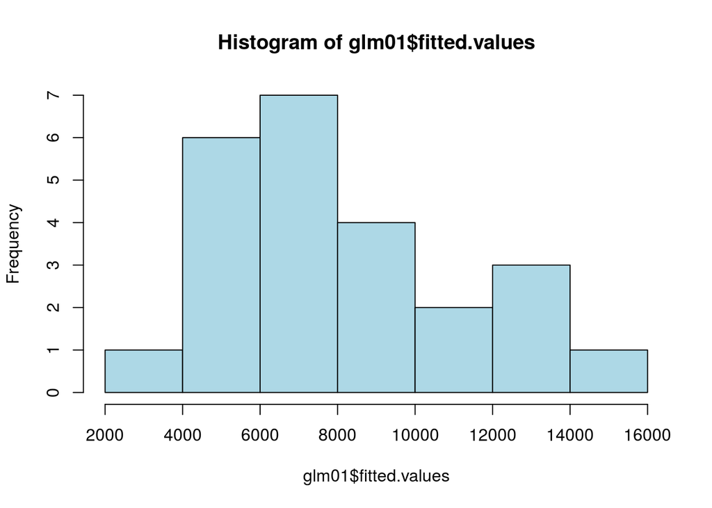

```r
hist(glm01$fitted.values,col="lightblue")
```

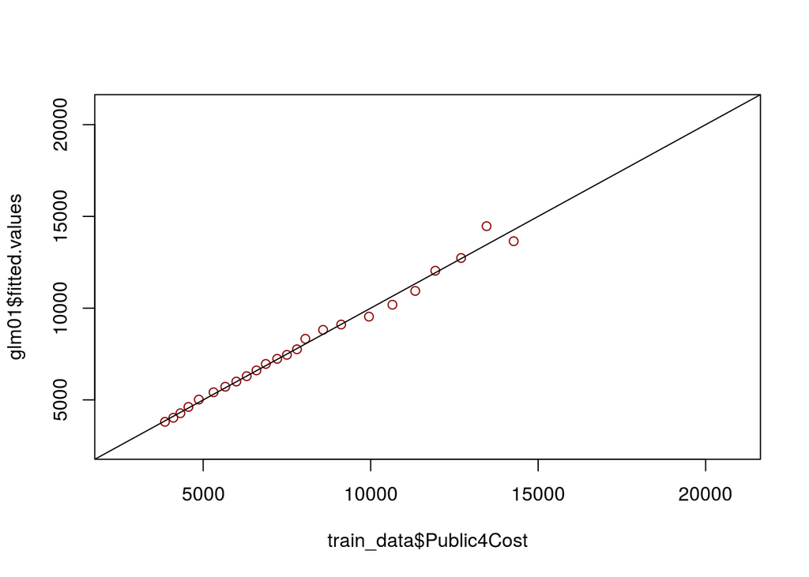

```r
# Conclusion: p < 0.05, therefore we reject null hypothesis and conclude that not all coefficient estimates are 0. There is association between cost and predictor variables in tandem

## check out fitted values against the originals
plot(train_data$Public4Cost, glm01$fitted.values, xlim = c(2500,20900), ylim = c(2500,20900),col="darkred")
abline(a=0, b=1)
```

```r
## MSE and RMSE
mean((glm01$fitted.values - train_data$Public4Cost)^2)
```

```
## [1] 89654.2
```

```r
sqrt(mean((glm01$fitted.values - train_data$Public4Cost)^2))
```

```
## [1] 299.4231
```

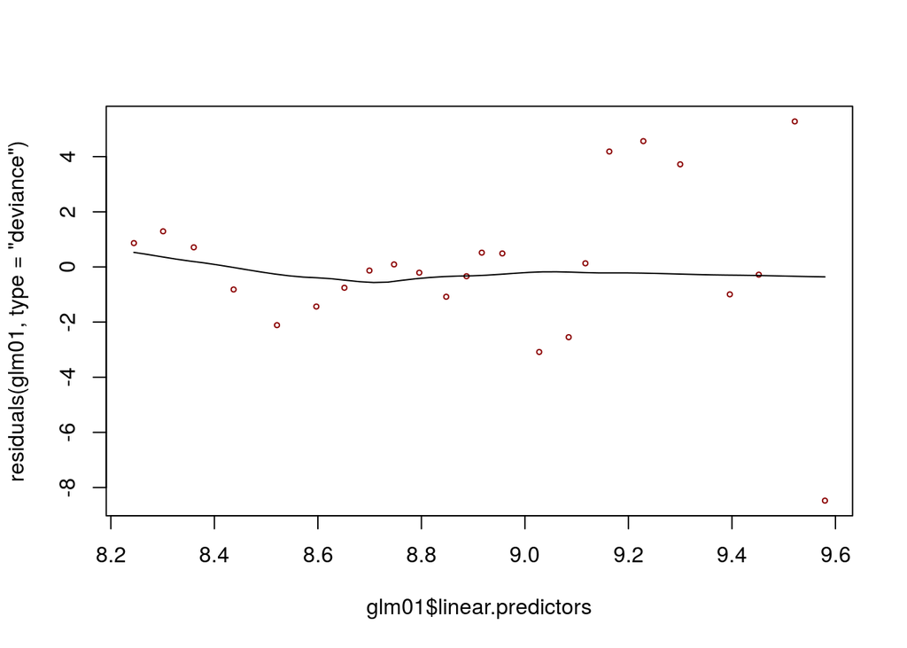

```r
# Pearson and deviance residual plots
scatter.smooth(glm01$linear.predictors,residuals(glm01,type="deviance"),cex=0.5,col="darkred")
```

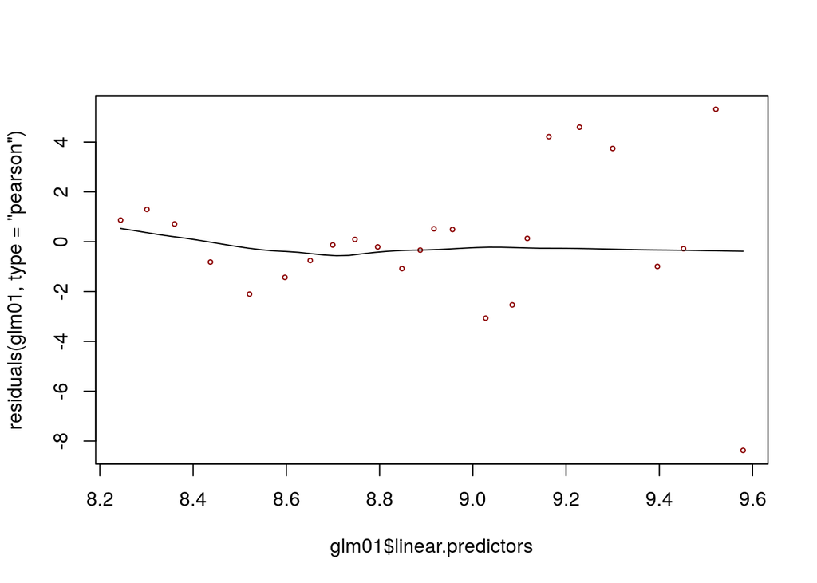

```r
scatter.smooth(glm01$linear.predictors,residuals(glm01,type="pearson"),cex=0.5,col="darkred")
```

######################### ## RANDOM FOREST MODEL #########################

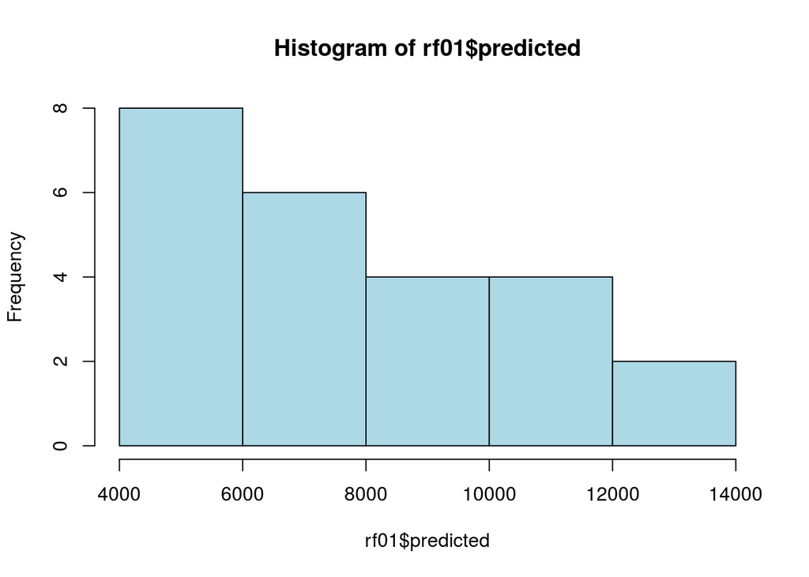

```r
## first, let's run a RF using a set of "standard" inputs.  Just to get a baseline
## set your seed so your model is reproducible
rf01 <- randomForest(Public4Cost ~ CPI + Debt_GDP + Debt_GDP * CPI,
                      data = train_data,
                      mtry = 2, ## roughly the standard pick for regression models
                      nodesize = 5, ## default for regression
                      maxnodes = NULL, ## again, default
                      ntree = 5000) ## 5 at first, to make sure it runs OK. Then enlarge

## review the model summary
hist(rf01$predicted,col="lightblue")
```

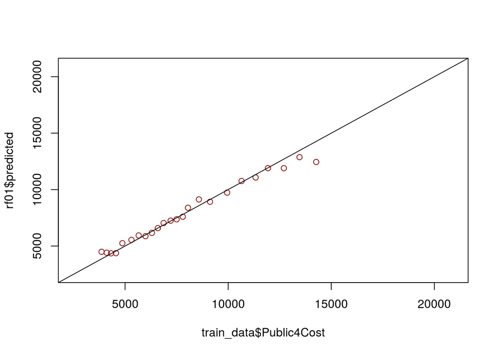

```r
## check out fitted values against the originals
plot(train_data$Public4Cost, rf01$predicted, xlim = c(2500,20900), ylim = c(2500,20900),col="darkred")
abline(a=0, b=1)
```

```r
## MSE and RMSE
mean((rf01$predicted - train_data$Public4Cost)^2)
```

```
## [1] 242561.4
```

```r
sqrt(mean((rf01$predicted - train_data$Public4Cost)^2))
```

```
## [1] 492.5052
```

## EVALUATE MODELS

[figure not shown]

```r
## rf01 and glm01
# Infer predictors - Infer how Debt_GDP and CPI predicts college 4 Year degree fees
pred_glm <- predict(glm01, newdata=test_data)
pred_rf <- predict(rf01, newdata=test_data)
pred_glm_exp <- exp(pred_glm)

hist(pred_rf)
```

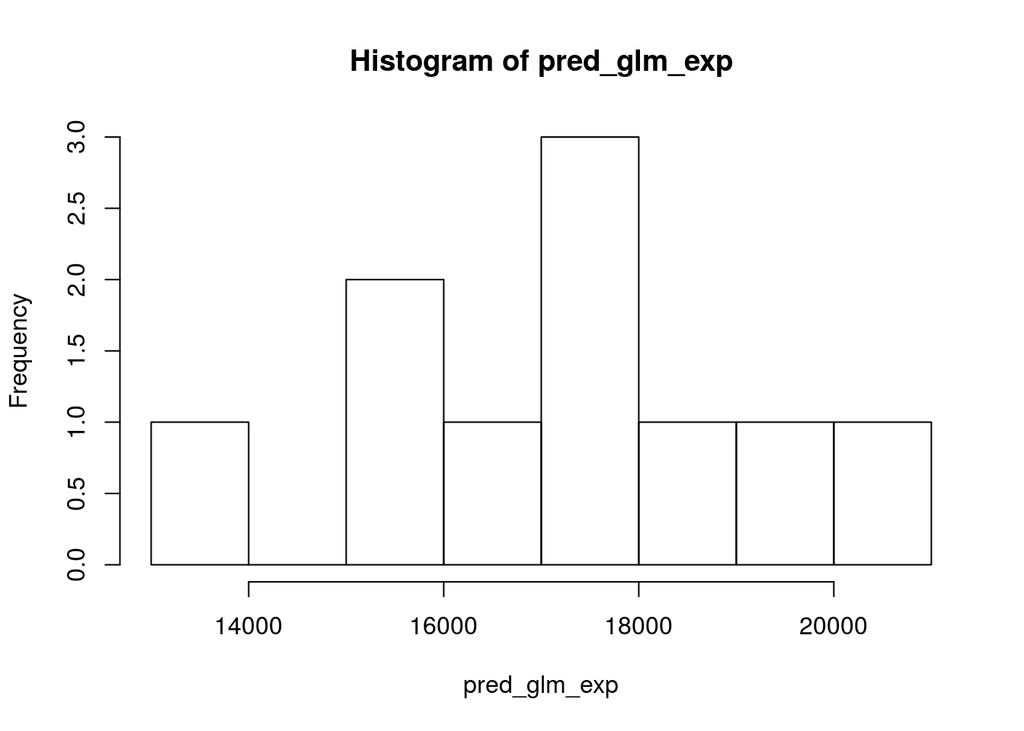

```r
hist(pred_glm_exp)
```

```r
## RMSE
sqrt(mean(pred_glm_exp - test_data$Public4Cost)^2)
```

```
## [1] 636.6545
```

```r
sqrt(mean(pred_rf - test_data$Public4Cost)^2)
```

```
## [1] 4740.12
```

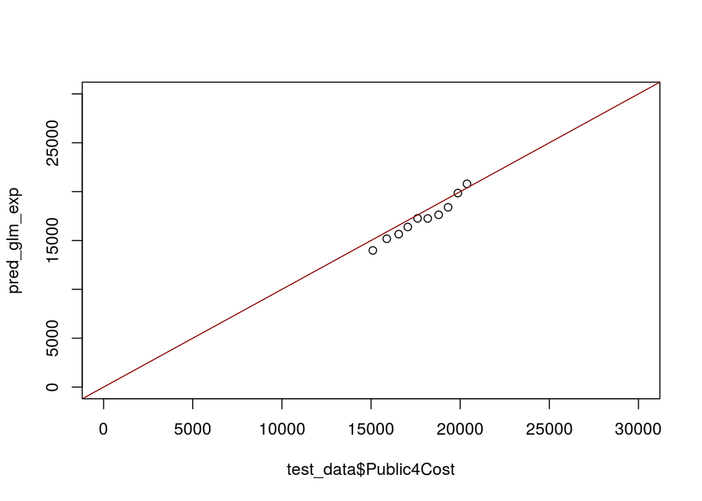

```r
plot(test_data$Public4Cost, pred_glm_exp,xlim = c(0, 30000), ylim = c(0, 30000))
abline(a=0,b=1,col="darkred")
```

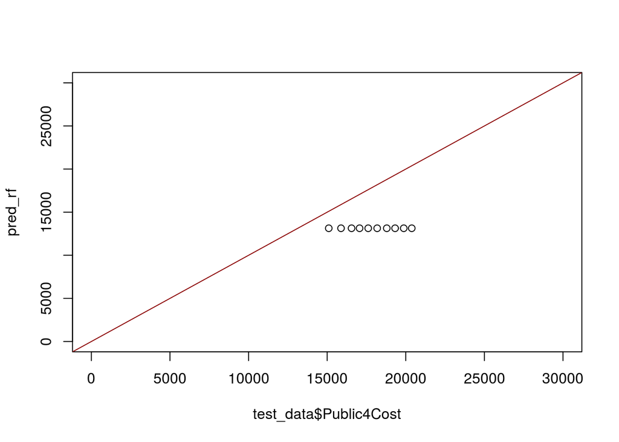

```r
plot(test_data$Public4Cost, pred_rf,xlim = c(0, 30000), ylim = c(0, 30000))
abline(a=0, b=1,col="darkred")
```

Comparing the 2 models – rf and GLM

```r
#--------Another approach--------------------------
#  Getting the parallel minimum between # 2 vectors consisting of ratio of predictedvalues to
# actual values and 1
probs_glm <- pmin((pred_glm_exp / test_data$Public4Cost), 1)
glm_accuracy = mean(probs_glm) * 100
glm_accuracy
```

```
## [1] 96.06059
```

```r
probs_rf <- pmin((pred_rf / test_data$Public4Cost), 1)
rf_accuracy = mean(probs_rf) * 100
rf_accuracy
```

```
## [1] 74.12801
```

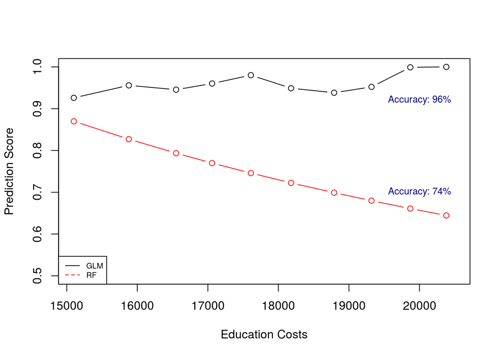

```r
par(xpd=TRUE)
plot(test_data$Public4Cost, probs_glm , type = "b", xlab = "Education Costs", ylab = "Prediction Score",xlim = c(15100, 20500),ylim=c(0.5,1))
lines(test_data$Public4Cost, probs_rf , type = "b", col = "red",xlim = c(15100, 20500))
legend("bottomleft",c("GLM","RF"),lty=1:2,col=1:2,cex=0.65)
text(20000,0.92,"Accuracy: 96%",col="darkblue",cex=0.8)
text(20000,0.7,"Accuracy: 74%",col="darkblue",cex=0.8)
```

## UTILITY FUNCTION

Let consider this scenario where based on the actual tuition fees, arbitrary bounds are chosen for utility calculation.

If the education saving is greater than 20900 and less than 23100, we don’t lose anything and we are safe. If we save less than 20900, we end up borrowing more in the future as predicted value is higher than this amount. Also, if we are saving more than the predicted amount, we compromise on the quality of life today by cancelling some family trips. In both the cases where I am not saving within the predicted range, let’s say I lose 10% of the value.

```r
## need to predict the tuition costs given 'Debt_GDP', 'Year' and Inflation index 'CPI' data. Predict tuition costs using test data and apply a utility function to it.

  values_glm = exp(predict(glm01, newdata=test_data))
  utilities_glm = ifelse(values_glm > 20900 && values_glm < 23100, values_glm * 1.0, values_glm * 0.9)

  values_rf = predict(rf01, newdata=test_data)
  utilities_rf = ifelse(values_glm > 20900 && values_glm < 23100, values_rf * 1.0, values_rf * 0.9)

  # Put it in a data.frame
D_plot_glm = data.frame(values_glm, utilities_glm)
D_plot_rf = data.frame(values_rf, utilities_rf)
```

Comparison of Utility function for different models

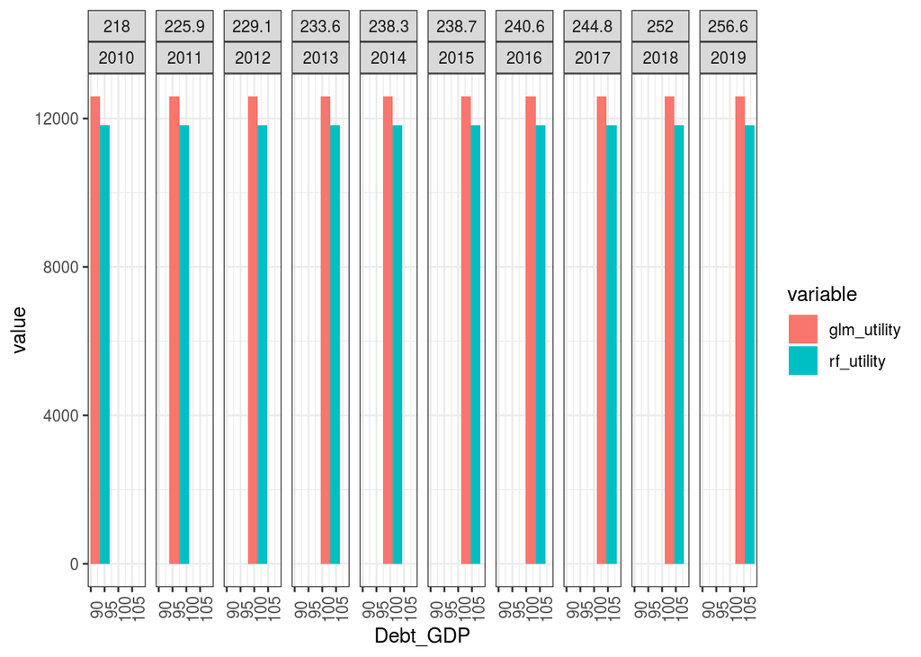

```r
tdata = data.frame(CPI=test_data$CPI,Debt_GDP=test_data$Debt_GDP,Year=test_data$Year)
df1 <- tdata %>% rowwise %>% do(W = as_tibble(.)) %>% ungroup

predicted_utility_glm = function(CPI,Debt_GDP,Year) {
  # Posterior predictive samples (values)
  values_glm = exp(predict(glm01, newdata=data.frame(CPI,Debt_GDP,Year), summary=FALSE))

  # Associated utilities. Posterior predictive utilities
  utilities_glm = ifelse(values_glm > 20900 && values_glm < 23100, values_glm * 1.0, values_glm * 0.9)
  utilities_glm  # Return it
}

predicted_utility_rf = function(CPI,Debt_GDP,Year) {
  # Posterior predictive samples (values)
  values_rf = predict(rf01, newdata=data.frame(CPI,Debt_GDP,Year), summary=FALSE)

  # Associated utilities. Posterior predictive utilities?
  utilities_rf = ifelse(values_rf  > 20900 && values_rf < 23100, values_rf * 1.0, values_rf * 0.9)
  utilities_rf  # Return it
}

D_plot_rf = tdata %>%
  mutate(rf_utility = predicted_utility_rf(tdata$CPI,tdata$Debt_GDP,tdata$Year)) %>% unnest
D_plot_glm = tdata %>%
  mutate(glm_utility = predicted_utility_glm(tdata$CPI,tdata$Debt_GDP,tdata$Year)) %>% unnest
#D_plot_all_one <- merge(D_plot_glm, D_plot_rf, by=c("CPI","Debt_GDP","Year"))
D_plot_all <- merge(D_plot_glm, D_plot_rf, by=c("CPI","Debt_GDP","Year"))
D_plot_l <- melt(D_plot_all, id.vars = c("CPI","Debt_GDP","Year"))
p <- ggplot(data = D_plot_l, aes(x = Debt_GDP, y = value, group = variable, fill = variable))
p <- p + geom_bar(stat = "identity", width = 7, position = "dodge")
p <- p + facet_grid(. ~ CPI+Year)
p <- p + theme_bw()
p <- p + theme(axis.text.x = element_text(angle = 90))
p
```

glm model zoomed in

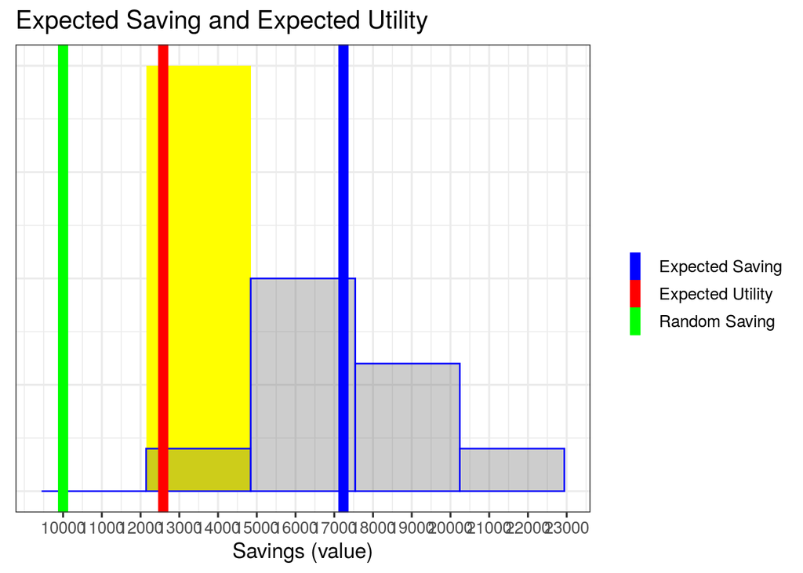

```r
# Plot it
ggplot(D_plot_glm) +
  # Histograms of posterior predictive
  geom_histogram(aes(x=utilities_glm), bins=5, fill='yellow') +
  geom_histogram(aes(x=values_glm), bins=5, col='blue', alpha=0.3) +

  # Lines for eted utility
  geom_vline(aes(xintercept=mean(utilities_glm), color='Expected Utility'), lwd=3, show.legend=TRUE) +
  geom_vline(aes(xintercept=mean(values_glm), color='Expected Saving'), lwd=3) +
  geom_vline(aes(xintercept=10000, color='Random Saving'), lwd=3) +

  # Styling
  labs(x = 'Savings (value)', y='', title='Expected Saving and Expected Utility') +
  scale_x_continuous(breaks=seq(10000, 25000, by=1000)) +
  theme_bw(13) +
  theme(axis.ticks.y = element_blank(), axis.title.y = element_blank(), axis.text.y = element_blank()) +

 # Legend
  scale_color_manual(name = "", values = c('Expected Saving'='blue', 'Expected Utility' = 'red', 'Random Saving'='green'))
```

```r
save.image("FinalModelEval.RData")

load("FinalModelEval.RData")
```